# Ford GoBike System - Effects of Ride Frequent & Ride Duration

## by Nivetha KS

## Investigation Overview

In this investigation, I wanted to look at the effects of Ride Frequent & Ride Duration influenced by ride time characteristics(Day, Month, Year) and Rider characteristics(Gender, User Type, Age).

## Dataset Overview

The dataset use in this investigation consists of Ford GoBike sharing system covering the greater San Francisco Bay area in the year 2017(June-December).Refer [Bay_Wheels_wikipedia](https://en.wikipedia.org/wiki/Bay_Wheels). It consists of various ride characteristics and riders characteristics.

Investigation focused on below features from the cleaned dataset:

- Trip Duration (seconds)
- Start Day
- Start Month
- Start Hour
- User Type (“Subscriber” = Member or “Customer” = Casual)
- Member Age
- Member Gender

## Relationship between Ride Frequency and Ride Duration

Intially distribution of ride duration has long tail and right skewed as dataset take on a very large range of values. So, I plotted the relationship on a logarithmic scale, the distribution of ride duration takes on a Unimodal shape and normally distributed.

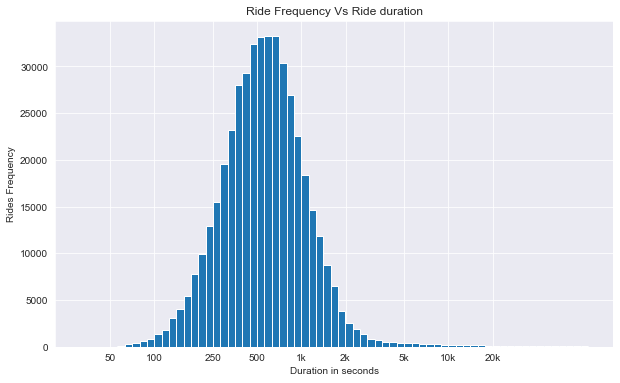

## Ride Frequency of User Type & Member Gender

- **Subcribers** have done more number of rides rather than **Customers**. As subscribed member ride price is less than casual customers, this might be the reason for more number of rides. Refer [Bay_Wheels_wikipedia](https://en.wikipedia.org/wiki/Bay_Wheels).
- **Male** riders counts are three times more than the **Female** riders. **Other** gender type is verly less when compared to other genders

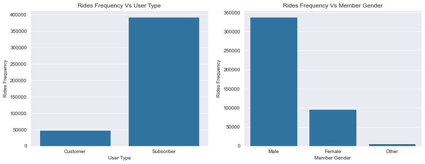

## Ride Duration for User Type & Member Gender

- Comparing to ride frequency, ride duration is higher for **Females** and **Other** genders rather than **Males** and **Customers** rather than **Subscribers**

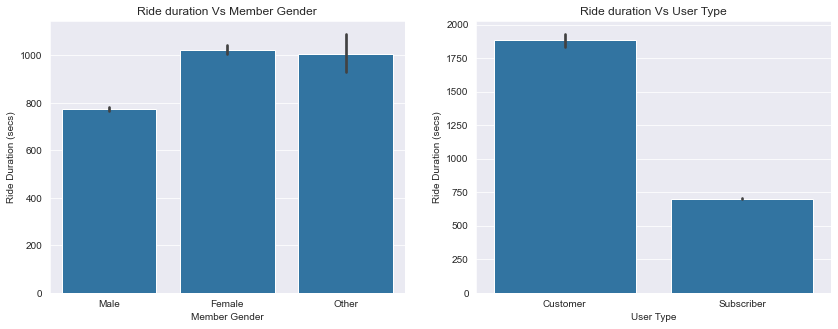

## Relationship between Ride Frequency, Ride duration and Member Age

- Most of riders age lies between **29 - 42** age range which indicates riders age infulences the ride frequency.
- Surprisingly all age group riders are uniformly distributed ride durations which means older riders are riding fast as well as the younger riders ranges approximately below 20k seconds

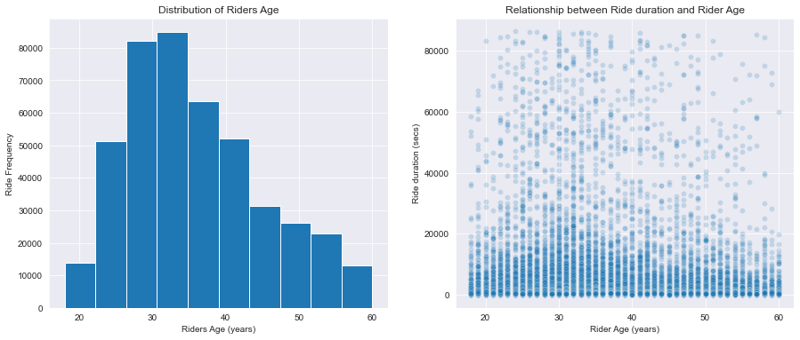

## Ride Frequency Vs Time Characteristics(Day, Month, Hour)

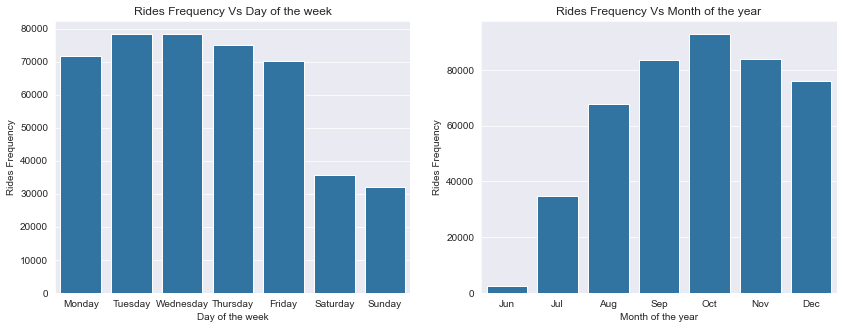

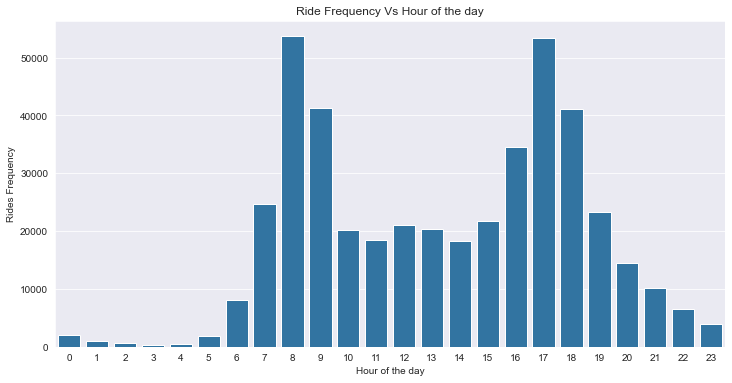

## Ride Duration Vs Time Characteristics(Day, Month, Hour)

- Relationship between time characteristics and ride duartion is totally differs from Relationship between time characteristics and peak frequency rides.
- Weekends rides are taking more ride duration over weekends. July month and 3 AM has higher ride durations.

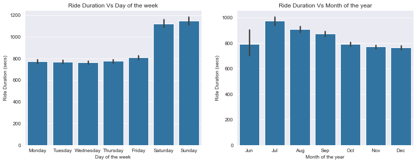

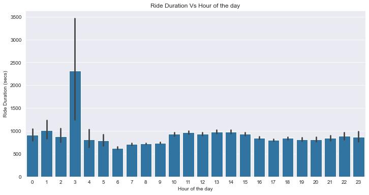

## Relationship between time characteristics and Riders characteristics(Gender, User Type) by ride Frequency

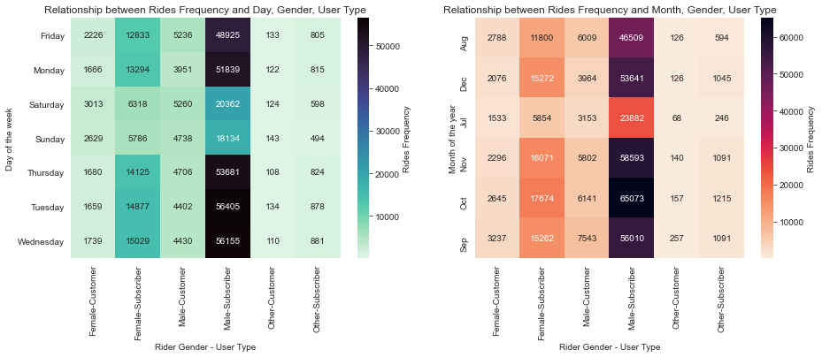

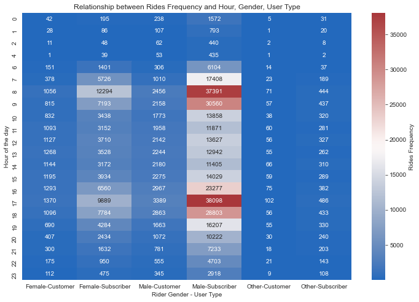

## Relationship between time characteristics and Riders characteristics(Gender, User Type) by Ride Duration

- **Ride Duration Peak times**(day: weekends - month: Jul-Aug, hour: 3AM)
- Overall subscribed Female riders and casual Other gender riders are taking more ride duration who rides the most during ride duration with respect to ride duration. Males are taking higer ride duration at specific timeframe Jun month and 3AM.

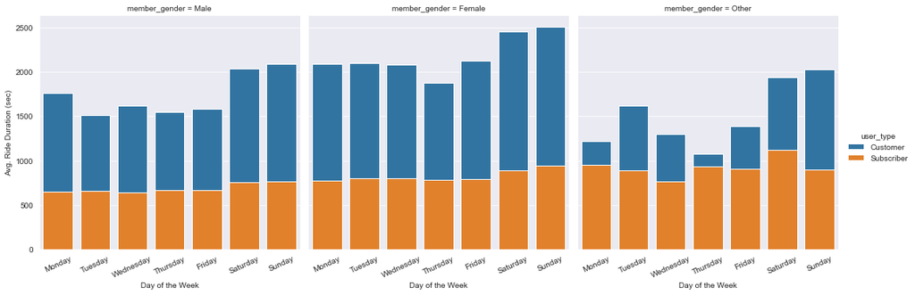

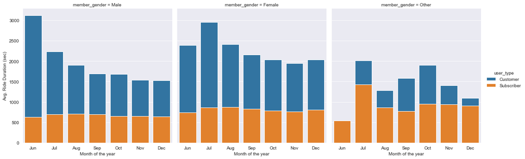

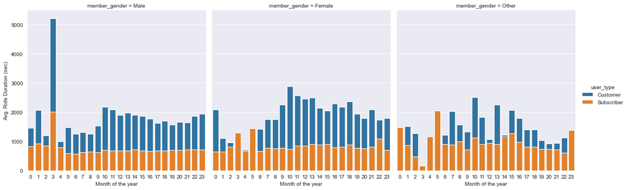

## Summary

According to my investigation, Ride Frequency is highly dependent on ride time characteristics and rider characteristics whereas Ride Duration isn't completetly associated with other data characteristics.